# "Breast Cancer Wisconsin (Diagnostic) Data Set" : Classifications

İlk olarak gerekli kütüphaneleri içe aktaralım.

```python
import pandas as pd
import numpy as np
import matplotlib.pyplot as plt
import seaborn as sns
import missingno as msno

import warnings
warnings.filterwarnings('ignore')

plt.style.use('ggplot')
```

Verimizi çekelim.

```python
data = pd.read_csv('C:/Users/emird/OneDrive/Masaüstü/data_mining/data.csv')
```

```python
data.head()
```

|  | id | diagnosis | radius_mean | texture_mean | perimeter_mean | area_mean | smoothness_mean | compactness_mean | concavity_mean | concave points_mean | ... | texture_worst | perimeter_worst | area_worst | smoothness_worst | compactness_worst | concavity_worst | concave points_worst | symmetry_worst | fractal_dimension_worst | Unnamed: 32 |
| --- | --- | --- | --- | --- | --- | --- | --- | --- | --- | --- | --- | --- | --- | --- | --- | --- | --- | --- | --- | --- | --- |
| 0 | 842302 | M | 17.99 | 10.38 | 122.80 | 1001.0 | 0.11840 | 0.27760 | 0.3001 | 0.14710 | ... | 17.33 | 184.60 | 2019.0 | 0.1622 | 0.6656 | 0.7119 | 0.2654 | 0.4601 | 0.11890 | NaN |
| 1 | 842517 | M | 20.57 | 17.77 | 132.90 | 1326.0 | 0.08474 | 0.07864 | 0.0869 | 0.07017 | ... | 23.41 | 158.80 | 1956.0 | 0.1238 | 0.1866 | 0.2416 | 0.1860 | 0.2750 | 0.08902 | NaN |
| 2 | 84300903 | M | 19.69 | 21.25 | 130.00 | 1203.0 | 0.10960 | 0.15990 | 0.1974 | 0.12790 | ... | 25.53 | 152.50 | 1709.0 | 0.1444 | 0.4245 | 0.4504 | 0.2430 | 0.3613 | 0.08758 | NaN |
| 3 | 84348301 | M | 11.42 | 20.38 | 77.58 | 386.1 | 0.14250 | 0.28390 | 0.2414 | 0.10520 | ... | 26.50 | 98.87 | 567.7 | 0.2098 | 0.8663 | 0.6869 | 0.2575 | 0.6638 | 0.17300 | NaN |
| 4 | 84358402 | M | 20.29 | 14.34 | 135.10 | 1297.0 | 0.10030 | 0.13280 | 0.1980 | 0.10430 | ... | 16.67 | 152.20 | 1575.0 | 0.1374 | 0.2050 | 0.4000 | 0.1625 | 0.2364 | 0.07678 | NaN |

5 rows × 33 columns

Verimize ait değişkenler hakkında :

- ID number
- Diagnosis (M = kötü huylu, B = iyi huylu)
- radius (hücre yarıçaplarının ortalaması)
- texture (gri skala değerlerinin standart sapması)
- perimeter
- area
- smoothness (yarıçap uzunluklarında yerel varyasyon)
- compactness (çevre^2 / alan - 1.0)
- concavity (şeklin içbükey kısımlarının şiddeti)
- concave points (şeklin içbükey kısımlarının sayısı)
- symmetry
- fractal dimension ("kıyı şeridi yaklaşımı" - 1)

Veri önişleme adımlarımızı gerçekleştirelim.

```python
data.drop(['id', 'Unnamed: 32'], axis=1, inplace=True)
```

```python
data.diagnosis.unique()
```

```
array(['M', 'B'], dtype=object)
```

```python
data['diagnosis'] = data['diagnosis'].apply(lambda x: 1 if x == 'M' else 0)
```

```python
data.head()
```

|  | diagnosis | radius_mean | texture_mean | perimeter_mean | area_mean | smoothness_mean | compactness_mean | concavity_mean | concave points_mean | symmetry_mean | ... | radius_worst | texture_worst | perimeter_worst | area_worst | smoothness_worst | compactness_worst | concavity_worst | concave points_worst | symmetry_worst | fractal_dimension_worst |
| --- | --- | --- | --- | --- | --- | --- | --- | --- | --- | --- | --- | --- | --- | --- | --- | --- | --- | --- | --- | --- | --- |
| 0 | 1 | 17.99 | 10.38 | 122.80 | 1001.0 | 0.11840 | 0.27760 | 0.3001 | 0.14710 | 0.2419 | ... | 25.38 | 17.33 | 184.60 | 2019.0 | 0.1622 | 0.6656 | 0.7119 | 0.2654 | 0.4601 | 0.11890 |
| 1 | 1 | 20.57 | 17.77 | 132.90 | 1326.0 | 0.08474 | 0.07864 | 0.0869 | 0.07017 | 0.1812 | ... | 24.99 | 23.41 | 158.80 | 1956.0 | 0.1238 | 0.1866 | 0.2416 | 0.1860 | 0.2750 | 0.08902 |
| 2 | 1 | 19.69 | 21.25 | 130.00 | 1203.0 | 0.10960 | 0.15990 | 0.1974 | 0.12790 | 0.2069 | ... | 23.57 | 25.53 | 152.50 | 1709.0 | 0.1444 | 0.4245 | 0.4504 | 0.2430 | 0.3613 | 0.08758 |
| 3 | 1 | 11.42 | 20.38 | 77.58 | 386.1 | 0.14250 | 0.28390 | 0.2414 | 0.10520 | 0.2597 | ... | 14.91 | 26.50 | 98.87 | 567.7 | 0.2098 | 0.8663 | 0.6869 | 0.2575 | 0.6638 | 0.17300 |
| 4 | 1 | 20.29 | 14.34 | 135.10 | 1297.0 | 0.10030 | 0.13280 | 0.1980 | 0.10430 | 0.1809 | ... | 22.54 | 16.67 | 152.20 | 1575.0 | 0.1374 | 0.2050 | 0.4000 | 0.1625 | 0.2364 | 0.07678 |

5 rows × 31 columns

```python
data.describe()
```

|  | diagnosis | radius_mean | texture_mean | perimeter_mean | area_mean | smoothness_mean | compactness_mean | concavity_mean | concave points_mean | symmetry_mean | ... | radius_worst | texture_worst | perimeter_worst | area_worst | smoothness_worst | compactness_worst | concavity_worst | concave points_worst | symmetry_worst | fractal_dimension_worst |
| --- | --- | --- | --- | --- | --- | --- | --- | --- | --- | --- | --- | --- | --- | --- | --- | --- | --- | --- | --- | --- | --- |
| count | 569.000000 | 569.000000 | 569.000000 | 569.000000 | 569.000000 | 569.000000 | 569.000000 | 569.000000 | 569.000000 | 569.000000 | ... | 569.000000 | 569.000000 | 569.000000 | 569.000000 | 569.000000 | 569.000000 | 569.000000 | 569.000000 | 569.000000 | 569.000000 |
| mean | 0.372583 | 14.127292 | 19.289649 | 91.969033 | 654.889104 | 0.096360 | 0.104341 | 0.088799 | 0.048919 | 0.181162 | ... | 16.269190 | 25.677223 | 107.261213 | 880.583128 | 0.132369 | 0.254265 | 0.272188 | 0.114606 | 0.290076 | 0.083946 |
| std | 0.483918 | 3.524049 | 4.301036 | 24.298981 | 351.914129 | 0.014064 | 0.052813 | 0.079720 | 0.038803 | 0.027414 | ... | 4.833242 | 6.146258 | 33.602542 | 569.356993 | 0.022832 | 0.157336 | 0.208624 | 0.065732 | 0.061867 | 0.018061 |
| min | 0.000000 | 6.981000 | 9.710000 | 43.790000 | 143.500000 | 0.052630 | 0.019380 | 0.000000 | 0.000000 | 0.106000 | ... | 7.930000 | 12.020000 | 50.410000 | 185.200000 | 0.071170 | 0.027290 | 0.000000 | 0.000000 | 0.156500 | 0.055040 |
| 25% | 0.000000 | 11.700000 | 16.170000 | 75.170000 | 420.300000 | 0.086370 | 0.064920 | 0.029560 | 0.020310 | 0.161900 | ... | 13.010000 | 21.080000 | 84.110000 | 515.300000 | 0.116600 | 0.147200 | 0.114500 | 0.064930 | 0.250400 | 0.071460 |
| 50% | 0.000000 | 13.370000 | 18.840000 | 86.240000 | 551.100000 | 0.095870 | 0.092630 | 0.061540 | 0.033500 | 0.179200 | ... | 14.970000 | 25.410000 | 97.660000 | 686.500000 | 0.131300 | 0.211900 | 0.226700 | 0.099930 | 0.282200 | 0.080040 |
| 75% | 1.000000 | 15.780000 | 21.800000 | 104.100000 | 782.700000 | 0.105300 | 0.130400 | 0.130700 | 0.074000 | 0.195700 | ... | 18.790000 | 29.720000 | 125.400000 | 1084.000000 | 0.146000 | 0.339100 | 0.382900 | 0.161400 | 0.317900 | 0.092080 |
| max | 1.000000 | 28.110000 | 39.280000 | 188.500000 | 2501.000000 | 0.163400 | 0.345400 | 0.426800 | 0.201200 | 0.304000 | ... | 36.040000 | 49.540000 | 251.200000 | 4254.000000 | 0.222600 | 1.058000 | 1.252000 | 0.291000 | 0.663800 | 0.207500 |

8 rows × 31 columns

```python
data.info()
```

```
<class 'pandas.core.frame.DataFrame'>
RangeIndex: 569 entries, 0 to 568
Data columns (total 31 columns):
 #   Column                   Non-Null Count  Dtype
---  ------                   --------------  -----
 0   diagnosis                569 non-null    int64
 1   radius_mean              569 non-null    float64
 2   texture_mean             569 non-null    float64
 3   perimeter_mean           569 non-null    float64
 4   area_mean                569 non-null    float64
 5   smoothness_mean          569 non-null    float64
 6   compactness_mean         569 non-null    float64
 7   concavity_mean           569 non-null    float64
 8   concave points_mean      569 non-null    float64
 9   symmetry_mean            569 non-null    float64
```

[output cut: 23 more lines]

```python
data.isna().sum()
```

```
diagnosis                  0
radius_mean                0
texture_mean               0
perimeter_mean             0
area_mean                  0
smoothness_mean            0
compactness_mean           0
concavity_mean             0
concave points_mean        0
symmetry_mean              0
fractal_dimension_mean     0
radius_se                  0
texture_se                 0
perimeter_se               0
area_se                    0
smoothness_se              0
compactness_se             0
concavity_se               0
concave points_se          0
symmetry_se                0
fractal_dimension_se       0
radius_worst               0
texture_worst              0
perimeter_worst            0
area_worst                 0
smoothness_worst           0
compactness_worst          0
concavity_worst            0
concave points_worst       0
symmetry_worst             0
fractal_dimension_worst    0
dtype: int64
```

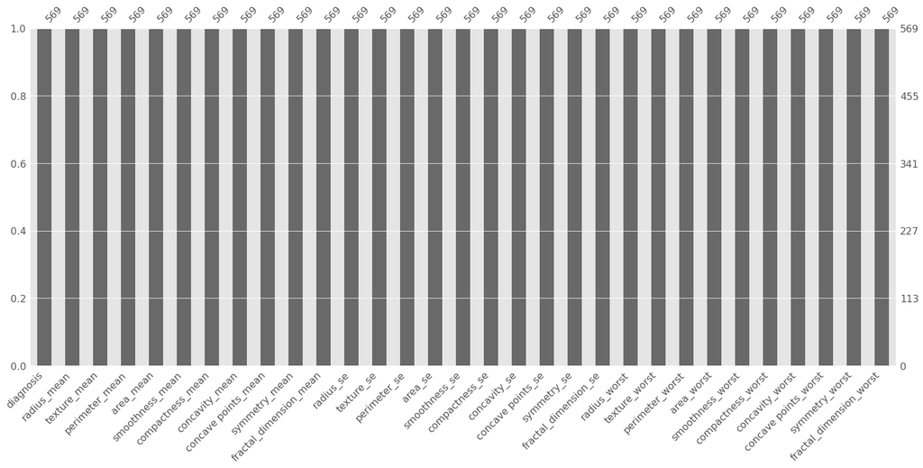

```python
msno.bar(data)
```

Son olarak keşifsel veri analizi yapabileceğimiz grafiklerimize, değişkenlerimizin dağılımlarına ve korelasyon matrisimize bakalım.

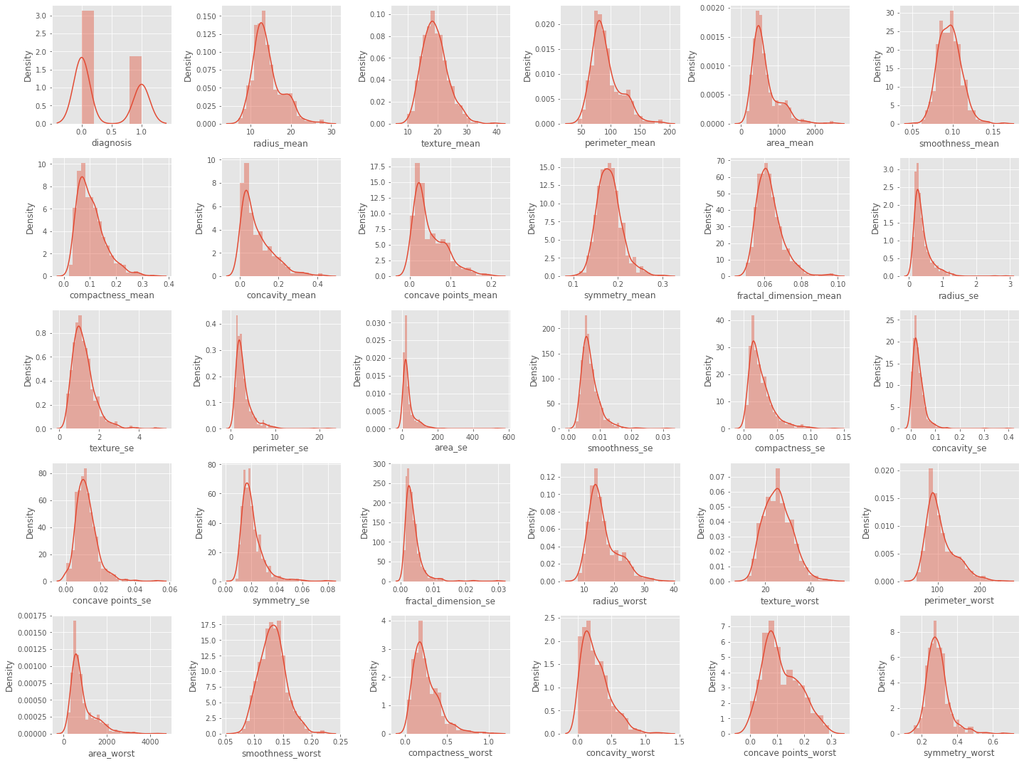

```python
plt.figure(figsize = (20,15))
plotnumber = 1

for column in data:
    if plotnumber <=30:
        ax = plt.subplot(5,6, plotnumber)
        sns.distplot(data[column])
        plt.xlabel(column)

    plotnumber += 1
plt.tight_layout()
plt.show()
```

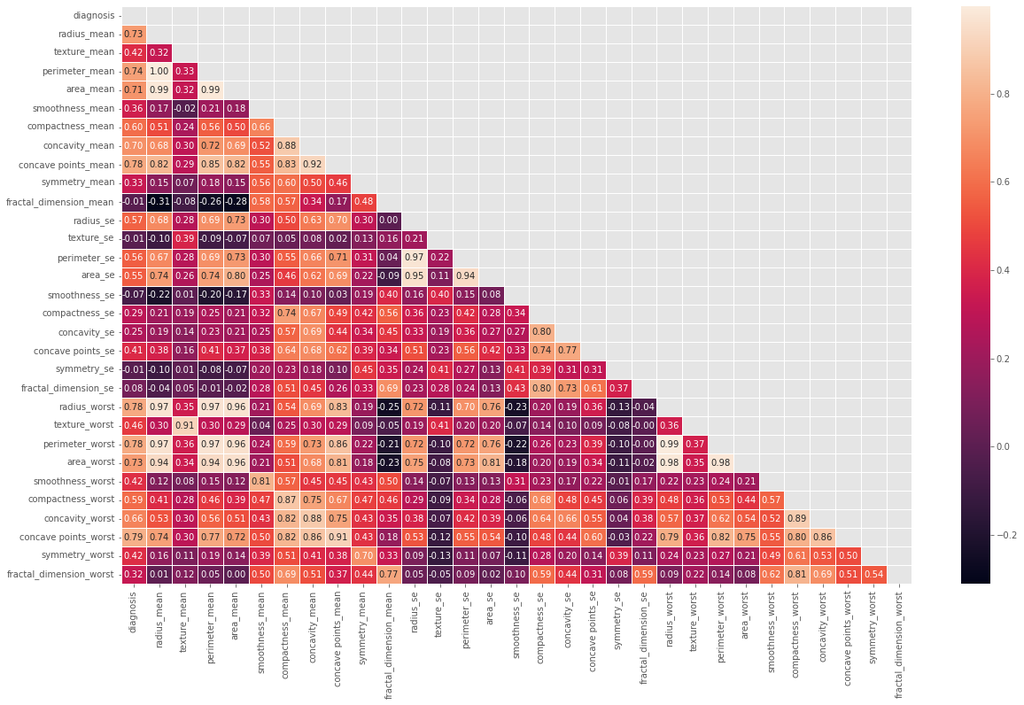

```python
plt.figure(figsize = (20,12))

corr = data.corr()
mask = np.triu(np.ones_like(corr, dtype = bool))

sns.heatmap(corr, mask = mask, linewidths = 1, annot = True, fmt = '.2f')
plt.show()
```

Korelasyon katsayısı fazlasıyla büyük olan çok sayıda değişken bulunmaktadır. Bu bizim için bir sorun teşkil etmektedir. Çünkü bu durum çoklu doğrusallığa neden olur, bu yüzden yüksek ilişkili özellikleri kaldırmamız gerekmektedir.

```python
corr_matrix = data.corr().abs()

mask = np.triu(np.ones_like(corr_matrix, dtype = bool))
tri_data = corr_matrix.mask(mask)

to_remove = [x for x in tri_data.columns if any(tri_data[x] > 0.92)]

data = data.drop(to_remove, axis = 1)

print(f'Aşırı korelasyonların çıkartıldığı yeni dataframe {data.shape[1]} sütuna sahiptir.')
```

```
Aşırı korelasyonların çıkartıldığı yeni dataframe 23 sütuna sahiptir.
```

```python
X = data.drop('diagnosis', axis = 1)
y = data['diagnosis']
```

```python
from sklearn.model_selection import train_test_split

X_train, X_test, y_train, y_test = train_test_split(X, y, test_size = 0.30, random_state = 0)

print(X_train.shape)
print(y_train.shape)
print(X_test.shape)
print(y_test.shape)
```

```
(398, 22)
(398,)
(171, 22)
(171,)
```

```python
from sklearn.preprocessing import StandardScaler

skaler = StandardScaler()

X_train = skaler.fit_transform(X_train)
X_test = skaler.transform(X_test)
```

# K Neighbors Classifier (KNN)

```python
from sklearn.neighbors import KNeighborsClassifier

knn = KNeighborsClassifier()
knn.fit(X_train, y_train)
```

```
KNeighborsClassifier()
```

Eğitim seti tahminleri ve tahminlerin olasılık değerleri :

```python
y_pred_knn_train = knn.predict(X_train)
y_pred_knn_train_pr = knn.predict_proba(X_train)
print(y_pred_knn_train_pr[0:10])
```

```
[[1. 0.]
 [1. 0.]
 [1. 0.]
 [0. 1.]
 [1. 0.]
 [1. 0.]
 [1. 0.]
 [1. 0.]
 [0. 1.]
 [0. 1.]]
```

Test seti tahminleri ve tahminlerin olasılık değerleri :

```python
y_pred_knn_test = knn.predict(X_test)
y_pred_knn_test_pr = knn.predict_proba(X_test)
print(y_pred_knn_test_pr[0:10])
```

```
[[0.  1. ]
 [0.8 0.2]
 [1.  0. ]
 [1.  0. ]
 [0.8 0.2]
 [1.  0. ]
 [1.  0. ]
 [1.  0. ]
 [1.  0. ]
 [1.  0. ]]
```

Eğitim ve test seti için accuracy değerlerimize bakalım.

```python
from sklearn.metrics import confusion_matrix, accuracy_score, mean_squared_error, r2_score , classification_report , roc_auc_score , roc_curve

print(accuracy_score(y_train, knn.predict(X_train)))
knn_acc = accuracy_score(y_test, knn.predict(X_test))
print(knn_acc)
```

```
0.9623115577889447
0.935672514619883
```

Eğitim seti için confusion matrixe bakalım.

```python
print(confusion_matrix(y_train, y_pred_knn_train))
```

```
[[243   6]
 [  9 140]]
```

249 tane 0'dan 243 tanesi ve 149 tane 1'den 140 tanesi doğru tahmin edilmiştir.

Test seti için confusion matrixe bakalım.

```python
print(confusion_matrix(y_test, y_pred_knn_test))
```

```
[[105   3]
 [  8  55]]
```

108 tane 0'dan 105 tanesi ve 63 tane 1'den 55 tanesi doğru tahmin edilmiştir.

ROC eğrisini çizdirelim ve modelimizi raporlayalım.

```
<function matplotlib.pyplot.show(close=None, block=None)>
```

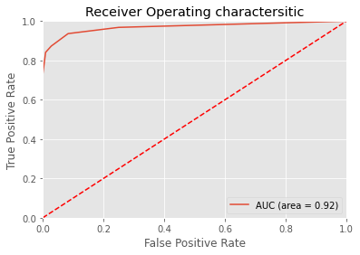

```python
Log_roc_auc = roc_auc_score(y_test, y_pred_knn_test)
fpr, tpr, thereholds = roc_curve(y_test, knn.predict_proba(X_test)[:,1])
plt.figure()
plt.plot(fpr, tpr, label = 'AUC (area = %0.2f)' % Log_roc_auc)
plt.plot([0,1], [0,1], 'r--')
plt.xlim([0.0, 1.0])
plt.ylim([0.0, 1.0])
plt.xlabel('False Positive Rate')
plt.ylabel('True Positive Rate')
plt.title('Receiver Operating charactersitic')
plt.legend(loc = 'lower right')
plt.savefig('Log_Roc')
plt.show
```

```python
print(classification_report(y_test, y_pred_knn_test))
```

```
              precision    recall  f1-score   support

           0       0.93      0.97      0.95       108
           1       0.95      0.87      0.91        63

    accuracy                           0.94       171
   macro avg       0.94      0.92      0.93       171
weighted avg       0.94      0.94      0.94       171
```

```python
from sklearn.model_selection import train_test_split, GridSearchCV , cross_val_score

knn_params = {'n_neighbors' : np.arange(1,750)}
knn_CV = KNeighborsClassifier()
knn_CVGS = GridSearchCV(knn_CV, knn_params, cv = 20,
                       n_jobs = -1, verbose = 2).fit(X_train, y_train)
```

```
Fitting 20 folds for each of 749 candidates, totalling 14980 fits
```

```python
knn_CVGS.best_params_
```

```
{'n_neighbors': 15}
```

```python
knn_CVGS_tuned = KNeighborsClassifier(n_neighbors = 15).fit(X_train, y_train)
```

```python
y_pred_knn_train_tuned = knn_CVGS_tuned.predict(X_train)
y_pred_knn_test_tuned = knn_CVGS_tuned.predict(X_test)
```

Belirlediğimiz en iyi parametre için oluşturduğumuz yeni eğitim ve test seti için accuracy değerlerimize bakalım.

```python
print(accuracy_score(y_train, y_pred_knn_train_tuned))
print(accuracy_score(y_test , y_pred_knn_test_tuned))
```

```
0.9547738693467337
0.9415204678362573
```

Eğitim setinin accucary skoru 0.962'den 0.954'e gerilerken test setinin accuracy skoru 0.935'den 0.941'e yükselmiştir.

Son olarak confusion matrixlere bakalım ve sınıflandırmamızı raporlayalım.

Eğitim seti için confusion matrixe bakalım.

```python
print(confusion_matrix(y_train, y_pred_knn_train_tuned))
```

```
[[246   3]
 [ 15 134]]
```

249 tane 0'dan 246 tanesi ve 149 tane 1'den 134 tanesi doğru tahmin edilmiştir.

Test seti için confusion matrixe bakalım.

```python
print(confusion_matrix(y_test, y_pred_knn_test_tuned))
```

```
[[105   3]
 [  7  56]]
```

108 tane 0'dan 105 tanesi ve 63 tane 1'den 56 tanesi doğru tahmin edilmiştir.

ROC eğrisini çizdirelim ve modelimizi raporlayalım.

```
<function matplotlib.pyplot.show(close=None, block=None)>
```

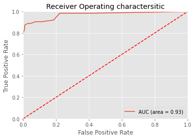

```python
Log_roc_auc = roc_auc_score(y_test, y_pred_knn_test_tuned)
fpr, tpr, thereholds = roc_curve(y_test, knn_CVGS.predict_proba(X_test)[:,1])
plt.figure()
plt.plot(fpr, tpr, label = 'AUC (area = %0.2f)' % Log_roc_auc)
plt.plot([0,1], [0,1], 'r--')
plt.xlim([0.0, 1.0])
plt.ylim([0.0, 1.0])
plt.xlabel('False Positive Rate')
plt.ylabel('True Positive Rate')
plt.title('Receiver Operating charactersitic')
plt.legend(loc = 'lower right')
plt.savefig('Log_Roc')
plt.show
```

```python
print(classification_report(y_test, y_pred_knn_test_tuned))
```

```
              precision    recall  f1-score   support

           0       0.94      0.97      0.95       108
           1       0.95      0.89      0.92        63

    accuracy                           0.94       171
   macro avg       0.94      0.93      0.94       171
weighted avg       0.94      0.94      0.94       171
```

# Decision Tree Classifier

```python
from sklearn.tree import DecisionTreeClassifier

dtc = DecisionTreeClassifier()

params = {'criterion' : ['gini', 'entropy'],
         'max_depth' : range(2, 50, 1),
         'min_samples_leaf' : range(5, 50, 5),
         'min_samples_split' : range(5, 25, 5),
         'splitter' : ['best', 'random']}

grid_search_dt = GridSearchCV(dtc, params, cv = 20,
                             n_jobs = -1, verbose = 1)
grid_search_dt.fit(X_train, y_train)
```

```
Fitting 20 folds for each of 6912 candidates, totalling 138240 fits
```

```
GridSearchCV(cv=20, estimator=DecisionTreeClassifier(), n_jobs=-1,
             param_grid={'criterion': ['gini', 'entropy'],
                         'max_depth': range(2, 50),
                         'min_samples_leaf': range(5, 50, 5),
                         'min_samples_split': range(5, 25, 5),
                         'splitter': ['best', 'random']},
             verbose=1)
```

```python
grid_search_dt.best_params_
```

```
{'criterion': 'gini',
 'max_depth': 44,
 'min_samples_leaf': 10,
 'min_samples_split': 20,
 'splitter': 'random'}
```

```python
grid_search_dt.best_score_
```

```
0.9548684210526315
```

```python
dtc = DecisionTreeClassifier(criterion = 'gini', max_depth = 44,
                            min_samples_leaf = 10,
                            min_samples_split = 20, splitter = 'random')
dtc.fit(X_train, y_train)
```

```
DecisionTreeClassifier(max_depth=44, min_samples_leaf=10, min_samples_split=20,
                       splitter='random')
```

Eğitim seti tahminleri ve tahminlerin olasılık değerleri :

```python
y_pred_dt_train = dtc.predict(X_train)
y_pred_dt_train_pr = dtc.predict_proba(X_train)
print(y_pred_dt_train_pr[0:10])
```

```
[[1.     0.    ]
 [1.     0.    ]
 [1.     0.    ]
 [0.0625 0.9375]
 [1.     0.    ]
 [1.     0.    ]
 [1.     0.    ]
 [1.     0.    ]
 [0.     1.    ]
 [0.     1.    ]]
```

Test seti tahminleri ve tahminlerin olasılık değerleri :

```python
y_pred_dt_test = dtc.predict(X_test)
y_pred_dt_test_pr = dtc.predict_proba(X_test)
print(y_pred_dt_test_pr[0:10])
```

```
[[0.11764706 0.88235294]
 [1.         0.        ]
 [0.9375     0.0625    ]
 [1.         0.        ]
 [0.9375     0.0625    ]
 [1.         0.        ]
 [1.         0.        ]
 [1.         0.        ]
 [1.         0.        ]
 [1.         0.        ]]
```

Eğitim ve test seti için accuracy değerlerimize bakalım.

```python
print(accuracy_score(y_pred_dt_train, dtc.predict(X_train)))
dt_acc = accuracy_score(y_pred_dt_test, dtc.predict(X_test))
print(dt_acc)
```

```
1.0
1.0
```

Eğitim seti için confusion matrixe bakalım.

```python
print(confusion_matrix(y_train, y_pred_dt_train))
```

```
[[231  18]
 [  9 140]]
```

249 tane 0'dan 231 tanesini ve 149 tane 1'den 140 tanesini doğru tahmin etmiştir.

Test seti için confusion matrixe bakalım.

```python
print(confusion_matrix(y_test, y_pred_dt_test))
```

```
[[92 16]
 [ 7 56]]
```

108 tane 0'dan 92 tanesini ve 63 tane 1'den 56 tanesini doğru tahmin etmiştir.

ROC eğrisini çizdirelim ve modelimizi raporlayalım.

```
<function matplotlib.pyplot.show(close=None, block=None)>
```

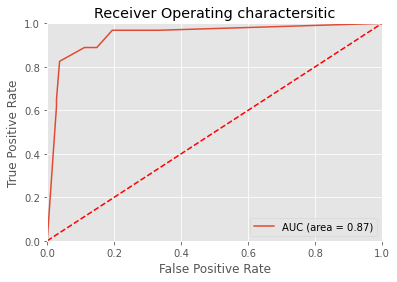

```python
Log_roc_auc = roc_auc_score(y_test, y_pred_dt_test)
fpr, tpr, thereholds = roc_curve(y_test, dtc.predict_proba(X_test)[:,1])
plt.figure()
plt.plot(fpr, tpr, label = 'AUC (area = %0.2f)' % Log_roc_auc)
plt.plot([0,1], [0,1], 'r--')
plt.xlim([0.0, 1.0])
plt.ylim([0.0, 1.0])
plt.xlabel('False Positive Rate')
plt.ylabel('True Positive Rate')
plt.title('Receiver Operating charactersitic')
plt.legend(loc = 'lower right')
plt.savefig('Log_Roc')
plt.show
```

```python
print(classification_report(y_test, y_pred_dt_test))
```

```
              precision    recall  f1-score   support

           0       0.93      0.85      0.89       108
           1       0.78      0.89      0.83        63

    accuracy                           0.87       171
   macro avg       0.85      0.87      0.86       171
weighted avg       0.87      0.87      0.87       171
```

# Random Forest Classifier

```python
from sklearn.ensemble import RandomForestClassifier

rnd = RandomForestClassifier(criterion = 'entropy',
                            max_depth = 11, max_features = 'auto',
                            min_samples_leaf = 2, min_samples_split = 3,
                            n_estimators = 130).fit(X_train, y_train)
```

Eğitim seti tahminleri ve tahminlerin olasılık değerleri :

```python
y_pred_rnd_train = rnd.predict(X_train)
y_pred_rnd_train_pr = rnd.predict_proba(X_train)
print(y_pred_rnd_train_pr[0:10])
```

```
[[1.         0.        ]
 [1.         0.        ]
 [0.99358974 0.00641026]
 [0.11974359 0.88025641]
 [1.         0.        ]
 [0.99615385 0.00384615]
 [0.9874359  0.0125641 ]
 [1.         0.        ]
 [0.14307692 0.85692308]
 [0.         1.        ]]
```

Test seti tahminleri ve tahminlerin olasılık değerleri :

```python
y_pred_rnd_test = rnd.predict(X_test)
y_pred_rnd_test_pr = rnd.predict_proba(X_test)
print(y_pred_rnd_test_pr[0:10])
```

```
[[0.01987179 0.98012821]
 [0.91076923 0.08923077]
 [0.99487179 0.00512821]
 [0.92935897 0.07064103]
 [0.93910256 0.06089744]
 [0.98769231 0.01230769]
 [0.98974359 0.01025641]
 [1.         0.        ]
 [0.96346154 0.03653846]
 [1.         0.        ]]
```

Eğitim ve test seti için accuracy değerlerimize bakalım.

```python
print(accuracy_score(y_train, rnd.predict(X_train)))
rnd_acc = accuracy_score(y_test, rnd.predict(X_test))
print(rnd_acc)
```

```
0.9949748743718593
0.9590643274853801
```

Eğitim seti için confusion matrixe bakalım.

```python
print(confusion_matrix(y_train, y_pred_rnd_train))
```

```
[[249   0]
 [  2 147]]
```

249 tane 0'dan hepsini ve 149 tane 1'den 147 tanesini doğru tahmin etmiştir.

Test seti için confusion matrixe bakalım.

```python
print(confusion_matrix(y_test, y_pred_rnd_test))
```

```
[[106   2]
 [  5  58]]
```

108 tane 0'dan 106 tanesini ve 63 tane 1'den 58 tanesini doğru tahmin etmiştir.

ROC eğrisini çizdirelim ve modelimizi raporlayalım.

```
<function matplotlib.pyplot.show(close=None, block=None)>
```

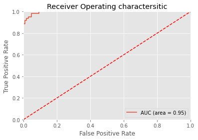

```python
Log_roc_auc = roc_auc_score(y_test, y_pred_rnd_test)
fpr, tpr, thereholds = roc_curve(y_test, rnd.predict_proba(X_test)[:,1])
plt.figure()
plt.plot(fpr, tpr, label = 'AUC (area = %0.2f)' % Log_roc_auc)
plt.plot([0,1], [0,1], 'r--')
plt.xlim([0.0, 1.0])
plt.ylim([0.0, 1.0])
plt.xlabel('False Positive Rate')
plt.ylabel('True Positive Rate')
plt.title('Receiver Operating charactersitic')
plt.legend(loc = 'lower right')
plt.savefig('Log_Roc')
plt.show
```

```python
print(classification_report(y_test, y_pred_rnd_test))
```

```
              precision    recall  f1-score   support

           0       0.95      0.98      0.97       108
           1       0.97      0.92      0.94        63

    accuracy                           0.96       171
   macro avg       0.96      0.95      0.96       171
weighted avg       0.96      0.96      0.96       171
```

# Gradient Boosting Classifier

```python
from sklearn.ensemble import GradientBoostingClassifier

gb = GradientBoostingClassifier()

params = {'loss' : ['deviance', 'exponential'],
         'learning_rate' : [0.001, 0.1, 0.5, 1, 5, 10],
         'n_estimators' : [100, 150, 180, 200, 250]}

grid_search_gb = GridSearchCV(gb, params, cv = 8, n_jobs = -1, verbose = 1)
grid_search_gb.fit(X_train, y_train)
```

```
Fitting 8 folds for each of 60 candidates, totalling 480 fits
```

```
GridSearchCV(cv=8, estimator=GradientBoostingClassifier(), n_jobs=-1,
             param_grid={'learning_rate': [0.001, 0.1, 0.5, 1, 5, 10],
                         'loss': ['deviance', 'exponential'],
                         'n_estimators': [100, 150, 180, 200, 250]},
             verbose=1)
```

```python
grid_search_gb.best_params_
```

```
{'learning_rate': 1, 'loss': 'deviance', 'n_estimators': 250}
```

```python
grid_search_gb.best_score_
```

```
0.9648979591836735
```

```python
gb = GradientBoostingClassifier(learning_rate = 1,
                               loss = 'deviance',
                               n_estimators = 250).fit(X_train, y_train)
```

Eğitim seti tahminleri ve tahminlerin olasılık değerleri :

```python
y_pred_gb_train = gb.predict(X_train)
y_pred_gb_train_pr = gb.predict_proba(X_train)
print(y_pred_gb_train_pr[0:10])
```

```
[[1.00000000e+00 5.94934190e-12]
 [1.00000000e+00 1.65199840e-11]
 [1.00000000e+00 3.27839939e-13]
 [6.36744346e-09 9.99999994e-01]
 [1.00000000e+00 6.29179121e-13]
 [1.00000000e+00 1.99449135e-10]
 [1.00000000e+00 2.88935089e-13]
 [1.00000000e+00 6.83160624e-14]
 [1.00485472e-08 9.99999990e-01]
 [8.17124146e-14 1.00000000e+00]]
```

Test seti tahminleri ve tahminlerin olasılık değerleri :

```python
y_pred_gb_test = gb.predict(X_test)
y_pred_gb_test_pr = gb.predict_proba(X_test)
print(y_pred_gb_test_pr[0:10])
```

```
[[5.85825610e-10 9.99999999e-01]
 [9.99997774e-01 2.22568569e-06]
 [1.00000000e+00 2.97960144e-14]
 [9.99999999e-01 1.46169670e-09]
 [1.00000000e+00 1.55516901e-13]
 [1.00000000e+00 1.49593056e-12]
 [9.99999999e-01 7.73354710e-10]
 [1.00000000e+00 1.92546649e-12]
 [1.00000000e+00 1.90472321e-10]
 [1.00000000e+00 1.85910209e-15]]
```

Eğitim ve test seti için accuracy değerlerimize bakalım.

```python
print(accuracy_score(y_train, y_pred_gb_train))
gb_acc = accuracy_score(y_test, y_pred_gb_test)
print(gb_acc)
```

```
1.0
0.9590643274853801
```

Eğitim seti için confusion matrixe bakalım.

```python
print(confusion_matrix(y_train, y_pred_gb_train))
```

```
[[249   0]
 [  0 149]]
```

249 tane 0'dan hepsini ve 149 tane 1'den hepsini doğru tahmin etmiştir.

Test seti için confusion matrixe bakalım.

```python
print(confusion_matrix(y_test, y_pred_gb_test))
```

```
[[105   3]
 [  4  59]]
```

108 tane 0'dan 105 tanesini ve 63 tane 1'den 59 tanesini doğru tahmin etmiştir.

ROC eğrisini çizdirelim ve modelimizi raporlayalım.

```
<function matplotlib.pyplot.show(close=None, block=None)>
```

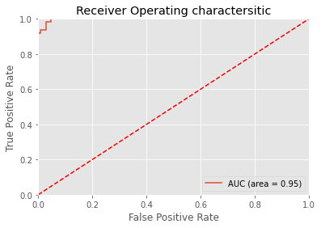

```python
Log_roc_auc = roc_auc_score(y_test, y_pred_gb_test)
fpr, tpr, thereholds = roc_curve(y_test, gb.predict_proba(X_test)[:,1])
plt.figure()
plt.plot(fpr, tpr, label = 'AUC (area = %0.2f)' % Log_roc_auc)
plt.plot([0,1], [0,1], 'r--')
plt.xlim([0.0, 1.0])
plt.ylim([0.0, 1.0])
plt.xlabel('False Positive Rate')
plt.ylabel('True Positive Rate')
plt.title('Receiver Operating charactersitic')
plt.legend(loc = 'lower right')
plt.savefig('Log_Roc')
plt.show
```

```python
print(classification_report(y_test, y_pred_gb_test))
```

```
              precision    recall  f1-score   support

           0       0.96      0.97      0.97       108
           1       0.95      0.94      0.94        63

    accuracy                           0.96       171
   macro avg       0.96      0.95      0.96       171
weighted avg       0.96      0.96      0.96       171
```

# Extreme Gradient Boosting

```python
from xgboost import XGBClassifier

xgb = XGBClassifier(objective = 'binary:logistic',
                   learning_rate = 0.75,
                   max_depth = 50,
                   n_estimators = 500).fit(X_train, y_train)
```

Eğitim seti tahminleri ve tahminlerin olasılık değerleri :

```python
y_pred_xgb_train = xgb.predict(X_train)
y_pred_xgb_train_proba = xgb.predict_proba(X_train)
print(y_pred_xgb_train_proba)
```

[output not shown]

[output cut: 343 more lines]

[output not shown]

Test seti tahminleri ve tahminlerin olasılık değerleri :

```python
y_pred_xgb_test = xgb.predict(X_test)
y_pred_xgb_test_pr = xgb.predict_proba(X_test)
print(y_pred_xgb_test_pr)
```

[output not shown]

[output cut: 116 more lines]

[output not shown]

Eğitim ve test seti için accuracy değerlerimize bakalım.

```python
print(accuracy_score(y_train, y_pred_xgb_train))
xgb_acc = accuracy_score(y_test, y_pred_xgb_test)
print(xgb_acc)
```

```
1.0
0.9766081871345029
```

Eğitim seti için confusion matrixe bakalım.

```python
print(confusion_matrix(y_train, y_pred_xgb_train))
```

```
[[249   0]
 [  0 149]]
```

249 tane 0'dan hepsini ve 149 tane 1'den hepsini doğru tahmin etmiştir.

Test seti için confusion matrixe bakalım.

```python
print(confusion_matrix(y_test, y_pred_xgb_test))
```

```
[[106   2]
 [  2  61]]
```

108 tane 0'dan 106 tanesini ve 63 tane 0'dan 61 tanesini doğru tahmin etmiştir.

ROC eğrisini çizdirelim ve modelimizi raporlayalım.

```
<function matplotlib.pyplot.show(close=None, block=None)>
```

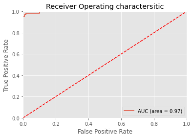

```python
Log_roc_auc = roc_auc_score(y_test, y_pred_xgb_test)
fpr, tpr, thereholds = roc_curve(y_test, xgb.predict_proba(X_test)[:,1])
plt.figure()
plt.plot(fpr, tpr, label = 'AUC (area = %0.2f)' % Log_roc_auc)
plt.plot([0,1], [0,1], 'r--')
plt.xlim([0.0, 1.0])
plt.ylim([0.0, 1.0])
plt.xlabel('False Positive Rate')
plt.ylabel('True Positive Rate')
plt.title('Receiver Operating charactersitic')
plt.legend(loc = 'lower right')
plt.savefig('Log_Roc')
plt.show
```

```python
print(classification_report(y_test, y_pred_xgb_test))
```

```
              precision    recall  f1-score   support

           0       0.98      0.98      0.98       108
           1       0.97      0.97      0.97        63

    accuracy                           0.98       171
   macro avg       0.97      0.97      0.97       171
weighted avg       0.98      0.98      0.98       171
```

Son olarak kurduğumuz modeller arasında kıyaslama yapmak isterse :

```python
models = pd.DataFrame({
    'Classification Model': ['KNN', 'Decision Tree Classifier', 'Random Forest Classifier',
             'Gradient Boosting Classifier', 'XgBoost'],
    'Score': [knn_acc, dt_acc, rnd_acc, gb_acc, xgb_acc]
})

models.sort_values(by = 'Score', ascending = False)
```

|  | Classification Model | Score |
| --- | --- | --- |
| 1 | Decision Tree Classifier | 1.000000 |
| 4 | XgBoost | 0.976608 |
| 2 | Random Forest Classifier | 0.959064 |
| 3 | Gradient Boosting Classifier | 0.959064 |
| 0 | KNN | 0.935673 |